# Lab 9

STA 602: Bayesian and Modern Statistics

Jan 25, 2024

```r
data(Gcsemv, package = "mlmRev")
dim(Gcsemv)
```

```
## [1] 1905    5
```

```r
summary(Gcsemv)
```

```
##      school        student     gender      written        course
##  68137  : 104   77     :  14   F:1128   Min.   : 1    Min.   :  9
##  68411  :  84   83     :  14   M: 777   1st Qu.:37    1st Qu.: 63
##  68107  :  79   53     :  13            Median :46    Median : 76
##  68809  :  73   66     :  13            Mean   :46    Mean   : 73
##  22520  :  65   27     :  12            3rd Qu.:55    3rd Qu.: 86
##  60457  :  54   110    :  12            Max.   :90    Max.   :100
##  (Other):1446   (Other):1827            NA's   :202   NA's   :180
```

```r
# Make Male the reference category and rename variable
Gcsemv$female <- relevel(Gcsemv$gender, "M")

# Use only total score on coursework paper
GCSE <- subset(x = Gcsemv,
               select = c(school, student, female, course))

# Count unique schools and students
m <- length(unique(GCSE$school))
N <- nrow(GCSE)
```

### Exercise 1 EDA

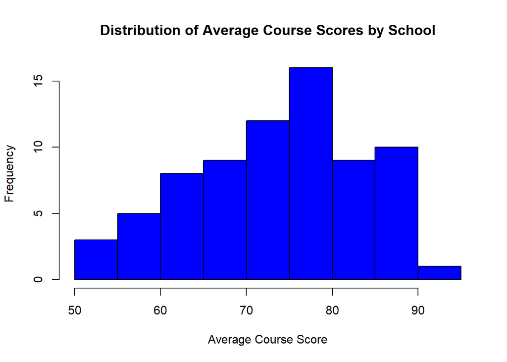

```r
average_scores <- aggregate(course ~ school, data=GCSE, FUN=mean)

hist(average_scores$course,
     main="Distribution of Average Course Scores by School",
     xlab="Average Course Score",
     ylab="Frequency",
     col="blue")
```

Fit the pooled and unpooled data

```r
pooled <- stan_glm(course ~ 1 + female, data = GCSE, refresh = 0)
unpooled <- stan_glm(course ~ -1 + school + female,data=GCSE, refresh = 0)
```

```r
mod1 <- stan_lmer(formula = course ~ 1 + (1 | school),
                  data = GCSE,
                  seed = 349,
                  refresh = 0)
```

```r
prior_summary(object = mod1)
```

```
## Priors for model 'mod1'
## ------
## Intercept (after predictors centered)
##   Specified prior:
##     ~ normal(location = 73, scale = 2.5)
##   Adjusted prior:
##     ~ normal(location = 73, scale = 41)
##
## Auxiliary (sigma)
##   Specified prior:
##     ~ exponential(rate = 1)
##   Adjusted prior:
##     ~ exponential(rate = 0.061)
##
## Covariance
##  ~ decov(reg. = 1, conc. = 1, shape = 1, scale = 1)
## ------
## See help('prior_summary.stanreg') for more details
```

```r
print(mod1, digits = 3)
```

```
## stan_lmer
##  family:       gaussian [identity]
##  formula:      course ~ 1 + (1 | school)
##  observations: 1725
## ------
##             Median MAD_SD
## (Intercept) 73.661  1.070
##
## Auxiliary parameter(s):
##       Median MAD_SD
## sigma 13.824  0.239
##
## Error terms:
##  Groups   Name        Std.Dev.
##  school   (Intercept)  8.852
##  Residual             13.821
## Num. levels: school 73
##
## ------
## * For help interpreting the printed output see ?print.stanreg
## * For info on the priors used see ?prior_summary.stanreg
```

### Exericise 2 Report the posterior summary

Estimates: mean sd 2.5% 97.5% (Intercept) 73.655 1.090 71.521 75.810 sigma 13.821 0.237 13.360 14.285 Sigma[school:(Intercept),(Intercept)] 78.361 15.728 52.686 113.567

```r
summary(mod1,
        pars = c("(Intercept)", "sigma", "Sigma[school:(Intercept),(Intercept)]"),
        probs = c(0.025, 0.975),
        digits = 3)
```

```
##
## Model Info:
##  function:     stan_lmer
##  family:       gaussian [identity]
##  formula:      course ~ 1 + (1 | school)
##  algorithm:    sampling
##  sample:       4000 (posterior sample size)
##  priors:       see help('prior_summary')
##  observations: 1725
##  groups:       school (73)
##
## Estimates:
##                                         mean    sd      2.5%    97.5%
## (Intercept)                            73.655   1.090  71.521  75.810
## sigma                                  13.821   0.237  13.360  14.285
## Sigma[school:(Intercept),(Intercept)]  78.361  15.728  52.686 113.567
##
## MCMC diagnostics
##                                       mcse  Rhat  n_eff
## (Intercept)                           0.045 1.008  581
## sigma                                 0.003 1.000 5143
## Sigma[school:(Intercept),(Intercept)] 0.561 1.002  785
##
## For each parameter, mcse is Monte Carlo standard error, n_eff is a crude measure of effective sample size, and Rhat is the potential scale reduction factor on split chains (at convergence Rhat=1).
```

```r
mod1_sims <- as.matrix(mod1)
dim(mod1_sims)
```

```
## [1] 4000   76
```

```r
## [1] 4000   76
par_names <- colnames(mod1_sims)
head(par_names)
```

```
## [1] "(Intercept)"                 "b[(Intercept) school:20920]"
## [3] "b[(Intercept) school:22520]" "b[(Intercept) school:22710]"
## [5] "b[(Intercept) school:22738]" "b[(Intercept) school:22908]"
```

```r
## [1] "(Intercept)"                 "b[(Intercept) school:20920]"
## [3] "b[(Intercept) school:22520]" "b[(Intercept) school:22710]"
## [5] "b[(Intercept) school:22738]" "b[(Intercept) school:22908]"
tail(par_names)
```

```
## [1] "b[(Intercept) school:76631]"
## [2] "b[(Intercept) school:77207]"
## [3] "b[(Intercept) school:84707]"
## [4] "b[(Intercept) school:84772]"
## [5] "sigma"
## [6] "Sigma[school:(Intercept),(Intercept)]"
```

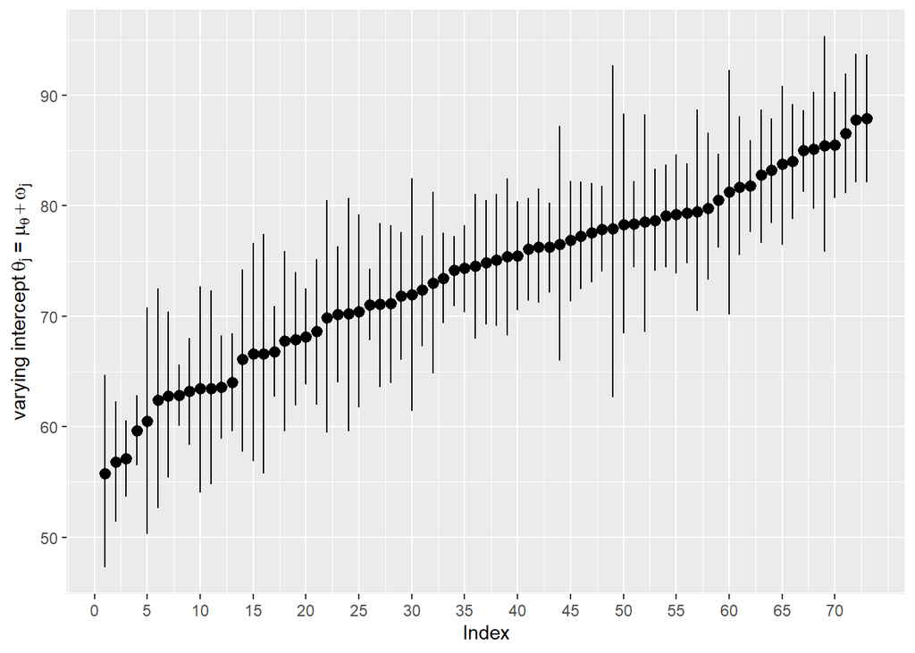

```r
## [1] "b[(Intercept) school:76631]"
## [2] "b[(Intercept) school:77207]"
## [3] "b[(Intercept) school:84707]"
## [4] "b[(Intercept) school:84772]"
## [5] "sigma"
## [6] "Sigma[school:(Intercept),(Intercept)]"
# obtain draws for mu_theta
mu_theta_sims <- as.matrix(mod1, pars = "(Intercept)")

# obtain draws for each school's contribution to intercept
omega_sim <- as.matrix(mod1,
                        regex_pars ="b\\[\\(Intercept\\) school\\:")


# to finish: obtain draws for sigma and tau^2
sig_sims <- as.matrix(mod1,
                      pars = "sigma")
tau2_sims <- as.matrix(mod1,
                       pars = "Sigma[school:(Intercept),(Intercept)]")




# posterior samples of intercepts, which is overall intercept + school-specific intercepts
int_sims <- as.numeric(mu_theta_sims) + omega_sim

# posterior mean
int_mean <- apply(int_sims, MARGIN = 2, FUN = mean)

# credible interval
int_ci <- apply(int_sims, MARGIN = 2, FUN = quantile, probs = c(0.025, 0.975))
int_ci <- data.frame(t(int_ci))

# combine into a single df
int_df <- data.frame(int_mean, int_ci)
names(int_df) <- c("post_mean","Q2.5", "Q97.5")

# sort DF according to posterior mean
int_df <- int_df[order(int_df$post_mean),]

# create variable "index" to represent order
int_df <- int_df %>% mutate(index = row_number())

# plot posterior means of school-varying intercepts, along with 95 CIs
ggplot(data = int_df, aes(x = index, y = post_mean))+
  geom_pointrange(aes(ymin = Q2.5, ymax = Q97.5))+
  scale_x_continuous("Index", breaks = seq(0,m, 5)) +
  scale_y_continuous(expression(paste("varying intercept ", theta[j], " = ", mu[theta]+omega[j])))
```

### Exercise 3 Compare the school 20920, 22520

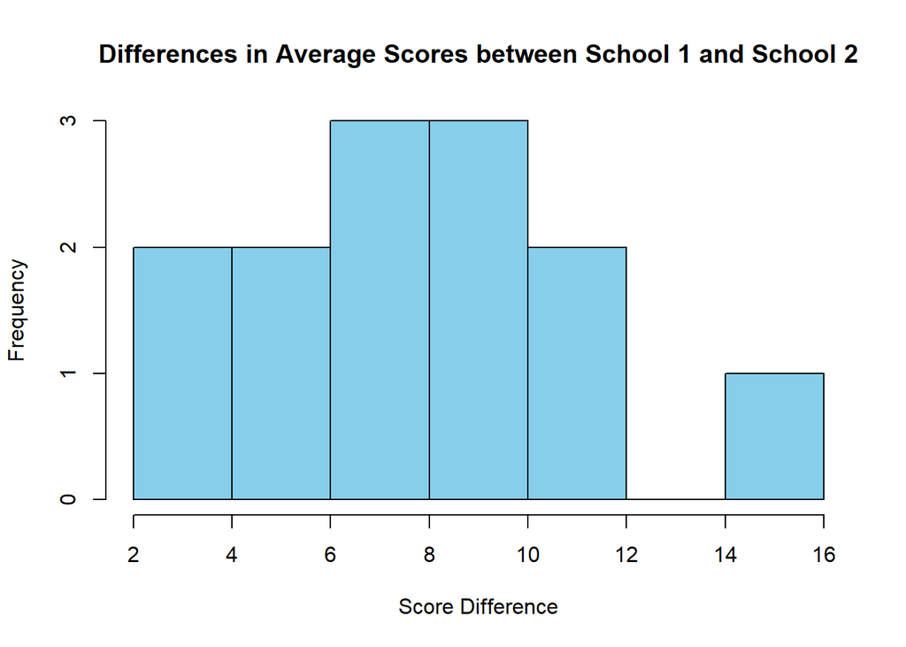

```r
# Calculate differences between the two schools
differences <- int_sims[1:13,1] - int_sims[1:13,2]

# Calculate descriptive statistics for the differences
summary_differences <- summary(differences)

hist(differences,
     main="Differences in Average Scores between School 1 and School 2",
     xlab="Score Difference",
     col="skyblue")
```

Consider Model 2:

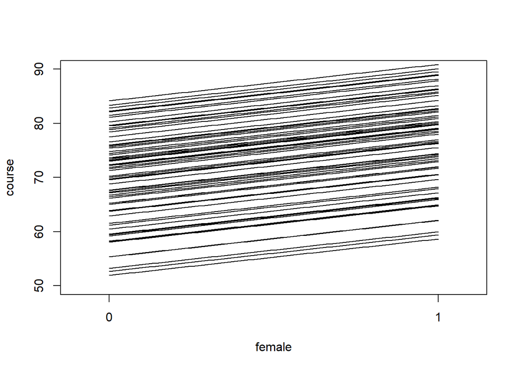

```r
mod2 <- stan_lmer(formula = course ~ 1 + female + (1 | school),
                  data = GCSE,
                  prior = normal(location = 0,
                                        scale = 100,
                                        autoscale = F),
                  prior_intercept = normal(location = 0,
                                        scale = 100,
                                        autoscale = F),
                  seed = 349,
                  refresh = 0)

# plot varying intercepts
mod2.sims <- as.matrix(mod2)
group_int <- mean(mod2.sims[,1])
mp <- mean(mod2.sims[,2])
bp <- apply(mod2.sims[, 3:75], 2, mean)
xvals <- seq(0,1,.01)
plot(x = xvals, y = rep(0, length(xvals)),
     ylim = c(50, 90), xlim = c(-0.1,1.1), xaxt = "n", xlab = "female", ylab = "course")
axis(side = 1, at = c(0,1))
for (bi in bp){
  lines(xvals, (group_int + bi)+xvals*mp)
}
```

### Exercise 4 Posterior estimate:

beta is femaleF

Estimates: mean sd 2.5% 97.5% (Intercept) 69.757 1.209 67.417 72.068 femaleF 6.720 0.683 5.377 8.036 sigma 13.423 0.237 12.965 13.887 Sigma[school:(Intercept),(Intercept)] 80.521 16.753 53.941 119.021

```r
summary(mod2,
        pars = c("(Intercept)", "sigma", "beta","Sigma[school:(Intercept),(Intercept)]"),
        probs = c(0.025, 0.975),
        digits = 3)
```

```
##
## Model Info:
##  function:     stan_lmer
##  family:       gaussian [identity]
##  formula:      course ~ 1 + female + (1 | school)
##  algorithm:    sampling
##  sample:       4000 (posterior sample size)
##  priors:       see help('prior_summary')
##  observations: 1725
##  groups:       school (73)
##
## Estimates:
##                                         mean    sd      2.5%    97.5%
## (Intercept)                            69.757   1.209  67.417  72.068
## femaleF                                 6.720   0.683   5.377   8.036
## sigma                                  13.423   0.237  12.965  13.887
## Sigma[school:(Intercept),(Intercept)]  80.521  16.753  53.941 119.021
##
## MCMC diagnostics
##                                       mcse  Rhat  n_eff
## (Intercept)                           0.043 1.005  784
## femaleF                               0.009 1.000 6010
## sigma                                 0.003 1.000 5947
## Sigma[school:(Intercept),(Intercept)] 0.637 1.004  691
##
## For each parameter, mcse is Monte Carlo standard error, n_eff is a crude measure of effective sample size, and Rhat is the potential scale reduction factor on split chains (at convergence Rhat=1).
```

Model 3

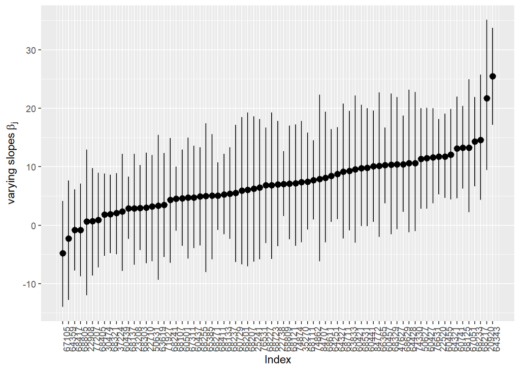

```r
mod3 <- stan_lmer(formula = course~ 1+ female + (1 + female | school),
                  data = GCSE,
                  seed = 349,
                  refresh = 0)
mod3_sims <- as.matrix(mod3)

# obtain draws for mu_theta
mu_theta_sims <- as.matrix(mod3, pars = "(Intercept)")

fem_sims <- as.matrix(mod3, pars = "femaleF")
# obtain draws for each school's contribution to intercept
omega_sims <- as.matrix(mod3,
                        regex_pars ="b\\[\\(Intercept\\) school\\:")
beta_sims <- as.matrix(mod3,
                       regex_pars ="b\\[femaleF school\\:")

int_sims <- as.numeric(mu_theta_sims) + omega_sims
slope_sims <- as.numeric(fem_sims) + beta_sims

# posterior mean
slope_mean <- apply(slope_sims, MARGIN = 2, FUN = mean)

# credible interval
slope_ci <- apply(slope_sims, MARGIN = 2, FUN = quantile, probs = c(0.025, 0.975))
slope_ci <- data.frame(t(slope_ci))

# combine into a single df
slope_df <- data.frame(slope_mean, slope_ci, levels(GCSE$school))
names(slope_df) <- c("post_mean","Q2.5", "Q97.5", "school")

# sort DF according to posterior mean
slope_df <- slope_df[order(slope_df$post_mean),]

# create variable "index" to represent order
slope_df <- slope_df %>% mutate(index = row_number())

# plot posterior means of school-varying slopes, along with 95% CIs
ggplot(data = slope_df, aes(x = index, y = post_mean))+
  geom_pointrange(aes(ymin = Q2.5, ymax = Q97.5))+
  scale_x_continuous("Index", breaks = seq(1,m, 1),
                     labels = slope_df$school) +
  scale_y_continuous(expression(paste("varying slopes ", beta[j])))+
  theme(axis.text.x = element_text(angle = 90))
```

Compare of the Model: Omit the code here

### Exercise 5 Compare Model

I will recommend mod3 since

mod3 0.0 0.0  
mod2 -30.6 9.9  
mod1 -79.7 15.0

Now go to the Minn Data

### Exercise 6 EDA

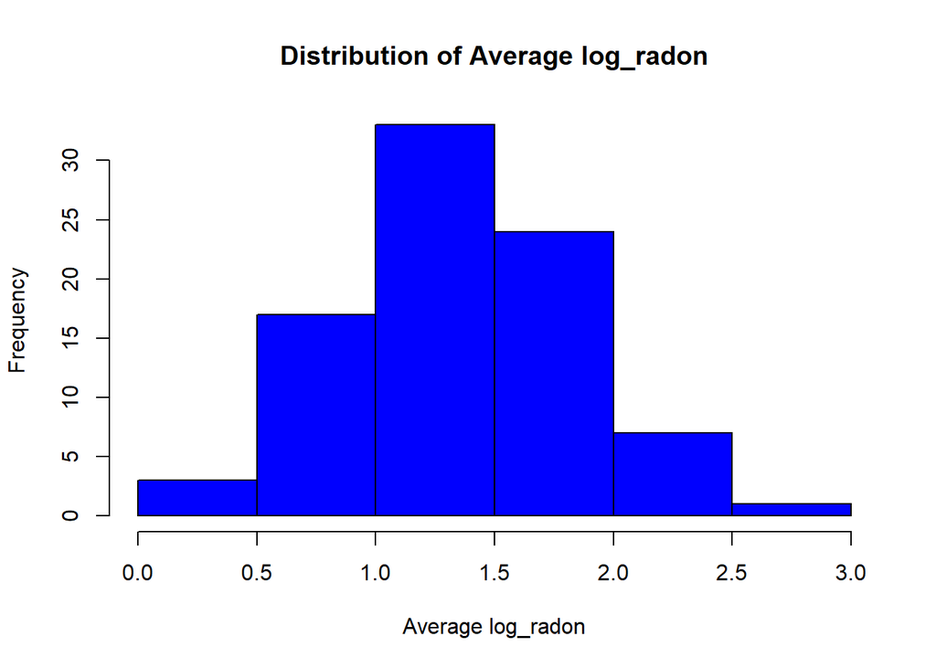

```r
radon <- read.csv("radon.txt", header = T,sep="")
radon$county <- as.factor(radon$county)


average_ra <- aggregate(log_radon ~ county, data=radon, FUN=mean)
hist(average_ra$log_radon,
     main="Distribution of Average log_radon",
     xlab="Average log_radon",
     ylab="Frequency",
     col="blue")
```

The groups are different!

### Exercise 7 pooled and unpooled

```r
radon.unpooled <- stan_glm(log_radon ~ -1 + county + floor, data=radon, refresh = 0)
radon.mod1 <- stan_lmer(formula = log_radon ~ 1 + (1 | county),
                  data = radon,
                  seed = 349,
                  refresh = 0)
```

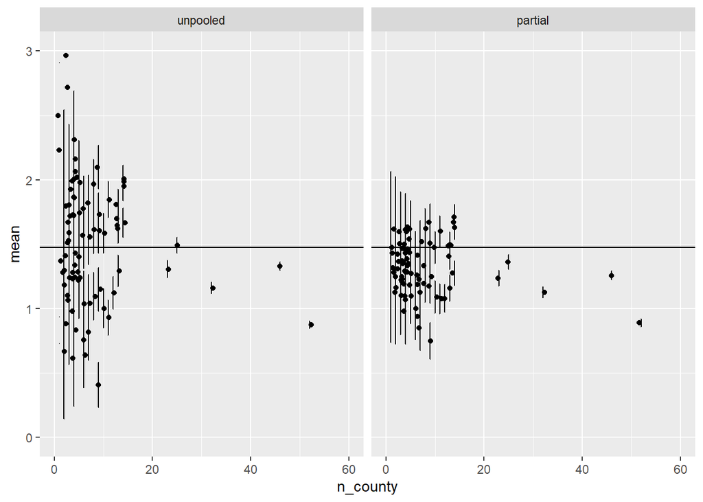

```r
n_county <- as.numeric(table(radon$county))
create_df <- function(sim,model){
  mean <- apply(sim,2,mean)
  sd <- apply(sim,2,sd)
  df <- cbind(n_county, mean, sd) %>%
    as.data.frame()%>%
    mutate(se = sd/ sqrt(n_county), model = model)
  return(df)
}

unpooled.sim <- as.matrix(radon.unpooled)
unpooled.df <- create_df(unpooled.sim[,1:85], model = "unpooled")


mod1.sim <- as.matrix(radon.mod1)[,1:86]
mod1.sim <- (mod1.sim[,1] + mod1.sim)[,-1]
partial.df <- create_df(mod1.sim, model = "partial")

ggplot(rbind(unpooled.df, partial.df)%>% mutate(model = factor(model, levels = c("unpooled", "partial"))), aes(x= n_county, y = mean)) +
   #draws the means
      geom_jitter() +
   #draws the CI error bars
      geom_errorbar(aes(ymin=mean-2*se, ymax= mean+2*se), width=.1)+
  ylim(0,3)+
  xlim(0,60)+
  geom_hline(aes(yintercept= mean(coef(radon.unpooled))))+
  facet_wrap(~model)
```

### Exercise 8 mod 2 mod3 mod 4

Fit a varying-intercept model, but now add the variable floor as a fixed slope. Call the model radon.mod2. For another model radon.mod3, fit a varying-intercept and varying-slope model, again with floor as the predictor.

```r
radon.mod2 <- stan_lmer(formula = log_radon ~ 1 +floor+ (1 | county),
                  data = radon,
                  seed = 349,
                  refresh = 0)



radon.mod3 <- stan_lmer(formula = log_radon ~ 1 +floor+ (1+floor | county),
                  data = radon,
                  seed = 349,
                  refresh = 0)
```

```r
radon.mod4 <- stan_lmer(formula = log_radon ~ 1 +floor+ (1 | county),
                  data = radon,
                  seed = 349,
                  refresh = 0)
```

```r
loo0 <- loo(radon.unpooled )
loo1 <- loo(radon.mod1)
loo2 <- loo(radon.mod2)
loo3 <- loo(radon.mod3)
loo4 <- loo(radon.mod4)
```

```r
loo_compare(loo0,loo1,loo2,loo3,loo4)
```

```
##                elpd_diff se_diff
## radon.mod2       0.0       0.0
## radon.mod4       0.0       0.0
## radon.mod3      -1.2       2.1
## radon.unpooled -26.5       6.5
## radon.mod1     -47.1      11.0
```

# Housekeeping

## R/RStudio

You all should have R and RStudio installed on your computers by now. If you do not, first install the latest version of R here: https://cran.rstudio.com (remember to select the right installer for your operating system). Next, install the latest version of RStudio here: https://www.rstudio.com/products/rstudio/download/. Scroll down to the “Installers for Supported Platforms” section and find the right installer for your operating system.

## R Markdown

You are required to use R Markdown to type up this lab report. If you do not already know how to use R markdown, refer to Sakai “Resources/Lab” folder for a very basic R Markdown template as well as a list of resources to help you learn how to use R markdown and LaTex.

## Gradescope

You MUST submit both your .Rmd and .pdf files to Gradescope. Make sure to knit to pdf and not html; ask the TA about knitting to pdf if you cannot figure it out. Be sure to submit under the right assignment entry.

# Getting started

This course will assume that you have some familiarity with the R programming language. However, to refresh your memory on some R key topics, this lab will go through some basic aspects of R functionality that will be important for future exercises.

# Acknowledgement

This lab was created by [Jordan Bryan](https://scholars.duke.edu/person/jordan.bryan) and [Becky Tang](https://scholars.duke.edu/person/becky.tang).